# Optimized Matrix Multiplication Algorithm Project

### This was my project for my undergraduate Analysis of Algorithms class. The idea was to create an algorithm that could compute matrix multiplication faster than the standard method of matrix multiplication, as that operation is extremely important in scientific computing and is always being used in fields like Machine Learning, Data Science and so much more.

I first began implementing the standard matrix multiplication which has an algorithmic complexity of $O(n^3)$. This method is very easy to implement but is expensive as it has many nested loops which makes this algorithm greedy and inneficient with large matrices multiplying together.

```python
import numpy as np

def matrix_multiplication(A, B):
    # Get the dimensions of the matrices
    rows_A, cols_A = A.shape
    rows_B, cols_B = B.shape

    # Check if the matrices can be multiplied
    if cols_A != rows_B:
        raise ValueError("Number of columns in A must be equal to number of rows in B")

    # Create the result matrix with zeros
    result = np.zeros((rows_A, cols_B))

    # Perform the matrix multiplication
    for i in range(rows_A):
        for j in range(cols_B):
            for k in range(cols_A):
                result[i, j] += A[i, k] * B[k, j]

    # Convert to integer if the result is a whole number
    if np.all(result == result.astype(int)):
        result = result.astype(int)

    return result

# Example usage
A = np.array([[1, 0, 0], [0, 2, 0], [0, 0, 3]])
B = np.array([[4, 0, 0], [0, 5, 0], [0, 0, 6]])
print(matrix_multiplication(A, B))
```

```
[[ 4  0  0]
 [ 0 10  0]
 [ 0  0 18]]
```

I then tried implementing a recursive approach to matrix multiplication, known as Strassen's Algorithm, which has a theoretical algorithmic complexity of $O(n^{2.81})$. In practice, this method absolutely tanked in performance with large matrices and performed even worse than the standard algorithm for matrix multiplication. However, this was a good learning experience, as an important lesson was learned with how recursion can really add up, computationally speaking

```python
def add_matrix(A, B):
    return [[A[i][j] + B[i][j] for j in range(len(A[0]))] for i in range(len(A))]

def subtract_matrix(A, B):
    return [[A[i][j] - B[i][j] for j in range(len(A[0]))] for i in range(len(A))]

def strassen_multiply(A, B):
    n = len(A)
    if n == 1:
        return [[A[0][0] * B[0][0]]]
    else:
        mid = n // 2

        A11 = [row[:mid] for row in A[:mid]]
        A12 = [row[mid:] for row in A[:mid]]
        A21 = [row[:mid] for row in A[mid:]]
        A22 = [row[mid:] for row in A[mid:]]

        B11 = [row[:mid] for row in B[:mid]]
        B12 = [row[mid:] for row in B[:mid]]
        B21 = [row[:mid] for row in B[mid:]]
        B22 = [row[mid:] for row in B[mid:]]

        M1 = strassen_multiply(add_matrix(A11, A22), add_matrix(B11, B22))
        M2 = strassen_multiply(add_matrix(A21, A22), B11)
        M3 = strassen_multiply(A11, subtract_matrix(B12, B22))
        M4 = strassen_multiply(A22, subtract_matrix(B21, B11))
        M5 = strassen_multiply(add_matrix(A11, A12), B22)
        M6 = strassen_multiply(subtract_matrix(A21, A11), add_matrix(B11, B12))
        M7 = strassen_multiply(subtract_matrix(A12, A22), add_matrix(B21, B22))

        C11 = add_matrix(subtract_matrix(add_matrix(M1, M4), M5), M7)
        C12 = add_matrix(M3, M5)
        C21 = add_matrix(M2, M4)
        C22 = add_matrix(subtract_matrix(add_matrix(M1, M3), M2), M6)

        C = []
        for i in range(mid):
            C.append(C11[i] + C12[i])
        for i in range(mid):
            C.append(C21[i] + C22[i])

        return C

# Example usage:
A = [[1, 2, 3, 4],
     [5, 6, 7, 8],
     [9, 10, 11, 12],
     [13, 14, 15, 16]]

B = [[16, 15, 14, 13],
     [12, 11, 10, 9],
     [8, 7, 6, 5],
     [4, 3, 2, 1]]

result = strassen_multiply(A, B)
print(np.array(result))
```

```
[[ 80  70  60  50]
 [240 214 188 162]
 [400 358 316 274]
 [560 502 444 386]]
```

My implementation has a SparseMatrix class that implements a sparse matrix using the CSR format, which is an efficient representation for storing and manipulating sparse matrices. Sparse matrices contain a significant number of zero elements, and the CSR format optimizes storage by only recording the non-zero elements. This class uses three lists to represent the matrix: values for storing non-zero elements, col_indices for the corresponding column indices, and row_pointers to indicate the starting and ending positions of each row in the values list. The add_value method inserts non-zero values into the matrix and dynamically updates the CSR structure.

Matrix multiplication is implemented in the multiply method, which computes the product of two sparse matrices efficiently by iterating over the non-zero elements. For each row of the first matrix, the method identifies non-zero values and multiplies them with the corresponding rows in the second matrix, storing the results in a temporary array that is later converted into the CSR format for the result matrix. Additionally, the to_dense method allows conversion of the sparse matrix back to a dense representation, useful for visualization or further operations. This method only stores the non-zero elements and their indices, along with the row pointers. Compared to dense matrix representation, the CSR format is much more efficient for sparse matrices.

This approach excels in scenarios where matrices are highly sparse, significantly reducing both memory usage and computational effort. However, it can be less effective when matrices are dense, as the benefits of sparsity diminish. Constructing the CSR format from dense data can incur overhead, and the multiplication method does not yet leverage parallelism, which could further improve performance for large-scale problems. Despite these limitations, the SparseMatrix class is a powerful tool for applications that involve large, sparse datasets, striking a balance between computational efficiency and memory optimization.

```python
class SparseMatrix:
    def __init__(self, rows, cols):
        self.rows = rows
        self.cols = cols
        self.values = []  # List to store non-zero values
        self.col_indices = []  # List to store column indices of the non-zero values
        self.row_pointers = [0]  # List to store the start index of each row in the values list

    def add_value(self, row, col, value):
        if value != 0:
            self.values.append(value)  # Add the non-zero value
            self.col_indices.append(col)  # Add the column index of the value
            if len(self.row_pointers) <= row + 1:
                # Extend row_pointers list if necessary
                self.row_pointers.extend([self.row_pointers[-1]] * (row + 1 - len(self.row_pointers) + 1))
            self.row_pointers[row + 1] += 1  # Increment the pointer for the next row

    def multiply(self, other):
        if self.cols != other.rows:
            raise ValueError("Matrix dimensions do not match for multiplication")

        result = SparseMatrix(self.rows, other.cols)  # Initialize the result matrix

        for i in range(self.rows):
            row_start = self.row_pointers[i]
            row_end = self.row_pointers[i + 1]
            row_values = self.values[row_start:row_end]
            row_indices = self.col_indices[row_start:row_end]

            result_row = [0] * other.cols  # Initialize the result row
            for j, value in zip(row_indices, row_values):
                other_row_start = other.row_pointers[j]
                other_row_end = other.row_pointers[j + 1]
                other_row_values = other.values[other_row_start:other_row_end]
                other_row_indices = other.col_indices[other_row_start:other_row_end]

                for k, other_value in zip(other_row_indices, other_row_values):
                    result_row[k] += value * other_value  # Perform multiplication and add to result row

            for col, value in enumerate(result_row):
                if value != 0:
                    result.add_value(i, col, value)  # Add non-zero values to the result matrix

        return result

    def to_dense(self):
        dense_matrix = [[0] * self.cols for _ in range(self.rows)]  # Initialize a dense matrix with zeros
        for i in range(self.rows):
            row_start = self.row_pointers[i]
            row_end = self.row_pointers[i + 1]
            for j in range(row_start, row_end):
                col = self.col_indices[j]
                dense_matrix[i][col] = self.values[j]  # Fill the dense matrix with non-zero values
        return dense_matrix

# Example usage:
A = SparseMatrix(3, 3)
A.add_value(0, 0, 1)
A.add_value(1, 1, 2)
A.add_value(2, 2, 3)

B = SparseMatrix(3, 3)
B.add_value(0, 0, 4)
B.add_value(1, 1, 5)
B.add_value(2, 2, 6)

C = A.multiply(B)
print(C.to_dense())
```

```
[[4, 0, 0], [0, 10, 0], [0, 0, 18]]
```

Finally, I made a plot that compares the computing time between the two algorithms and we can observe that the optimized algorithm is significantly quicker at computing matrix products than the standard method is.

```
Testing matrix size: 2x2
Testing matrix size: 4x4
Testing matrix size: 5x5
Testing matrix size: 10x10
Testing matrix size: 20x20
Testing matrix size: 50x50
Testing matrix size: 100x100
Testing matrix size: 150x150
Testing matrix size: 200x200
Testing matrix size: 250x250
Testing matrix size: 300x300
Testing matrix size: 400x400
Testing matrix size: 500x500
Testing matrix size: 600x600
Testing matrix size: 800x800
Testing matrix size: 1000x1000
```

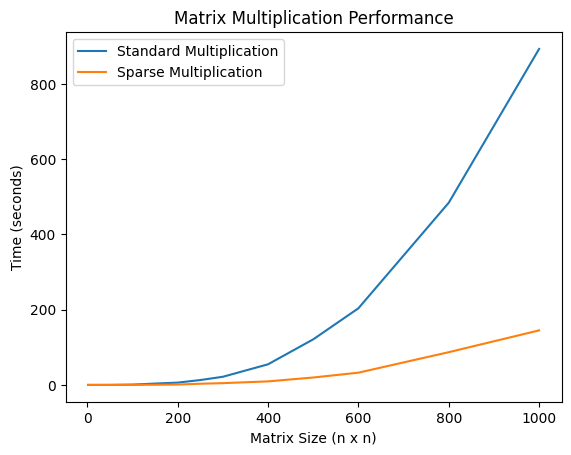

```python
import time
import matplotlib.pyplot as plt

def graph_performance():
    sizes = [2, 4, 5, 10, 20, 50, 100, 150, 200, 250, 300, 400, 500, 600, 800, 1000]
    standard_times = []
    sparse_times = []

    for size in sizes:
        print(f"Testing matrix size: {size}x{size}")
        A = np.random.randint(0, 10, (size, size))
        B = np.random.randint(0, 10, (size, size))

        # Standard multiplication
        start_time = time.time()
        matrix_multiplication(A, B)
        standard_times.append(time.time() - start_time)

        # Sparse multiplication
        sparse_A = SparseMatrix(size, size)
        sparse_B = SparseMatrix(size, size)
        for i in range(size):
            for j in range(size):
                sparse_A.add_value(i, j, A[i, j])
                sparse_B.add_value(i, j, B[i, j])

        start_time = time.time()
        sparse_A.multiply(sparse_B)
        sparse_times.append(time.time() - start_time)

    plt.plot(sizes, standard_times, label='Standard Multiplication')
    plt.plot(sizes, sparse_times, label='Sparse Multiplication')
    plt.xlabel('Matrix Size (n x n)')
    plt.ylabel('Time (seconds)')
    plt.title('Matrix Multiplication Performance')
    plt.legend()
    plt.show()

# Call the graph performance function
graph_performance()
```

```python
!jupyter nbconvert --to html Cubic_Spline.ipynb
```